# Codebook for debtlevels

Autogenerated data summary from dataReporter

2022-02-28 20:30:21

# Data report overview

The dataset examined has the following dimensions:

| Feature | Result |
| --- | --- |
| Number of observations | 832 |
| Number of variables | 11 |

# Codebook summary table

| Label | Variable | Class | # unique values | Missing | Description |
| --- | --- | --- | --- | --- | --- |
|  | **state** | character | 52 | 0.00 % |  |
|  | **year** | character | 16 | 0.00 % |  |
|  | **population** | numeric | 828 | 0.24 % |  |
|  | **auto** | numeric | 299 | 0.36 % |  |
|  | **creditcard** | numeric | 233 | 0.36 % |  |
|  | **mortgage** | numeric | 732 | 0.36 % |  |
|  | **studentloan** | numeric | 433 | 0.36 % |  |
|  | **auto_delinq** | numeric | 511 | 0.36 % |  |
|  | **creditcard_delinq** | numeric | 599 | 0.36 % |  |
|  | **mortgage_delinq** | numeric | 568 | 0.36 % |  |
|  | **studentloan_delinq** | numeric | 660 | 0.36 % |  |

# Variable list

## state

| Feature | Result |
| --- | --- |
| Variable type | character |
| Number of missing obs. | 0 (0 %) |
| Number of unique values | 52 |
| Mode | “AK” |

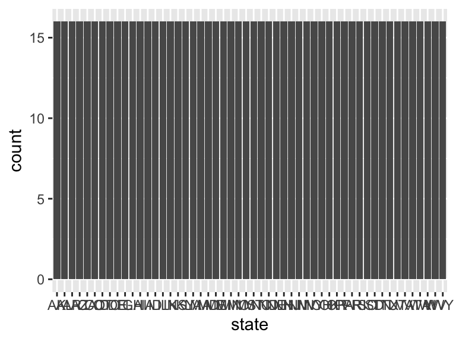

- Observed factor levels: "AK", "AL", "AR", "AZ", "CA", "CO", "CT", "DC", "DE", "FL", "GA", "HI", "IA", "ID", "IL", "IN", "KS", "KY", "LA", "MA", "MD", "ME", "MI", "MN", "MO", "MS", "MT", "NC", "ND", "NE", "NH", "NJ", "NM", "NV", "NY", "OH", "OK", "OR", "PA", "PR", "RI", "SC", "SD", "TN", "TX", "UT", "VA", "VT", "WA", "WI", "WV", "WY".

## year

| Feature | Result |
| --- | --- |
| Variable type | character |
| Number of missing obs. | 0 (0 %) |
| Number of unique values | 16 |
| Mode | “2004” |

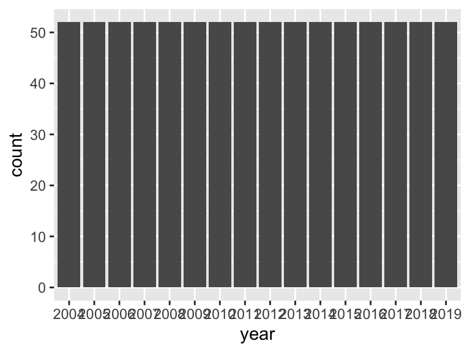

- Observed factor levels: "2004", "2005", "2006", "2007", "2008", "2009", "2010", "2011", "2012", "2013", "2014", "2015", "2016", "2017", "2018", "2019".

## population

| Feature | Result |
| --- | --- |
| Variable type | numeric |
| Number of missing obs. | 2 (0.24 %) |
| Number of unique values | 827 |
| Median | 3375690 |
| 1st and 3rd quartiles | 1356990; 5554720 |
| Min. and max. | 408220; 31718340 |

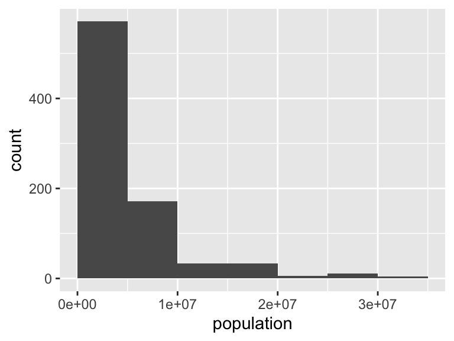

## auto

| Feature | Result |
| --- | --- |
| Variable type | numeric |
| Number of missing obs. | 3 (0.36 %) |
| Number of unique values | 298 |
| Median | 3420 |
| 1st and 3rd quartiles | 2920; 4110 |
| Min. and max. | 2030; 6880 |

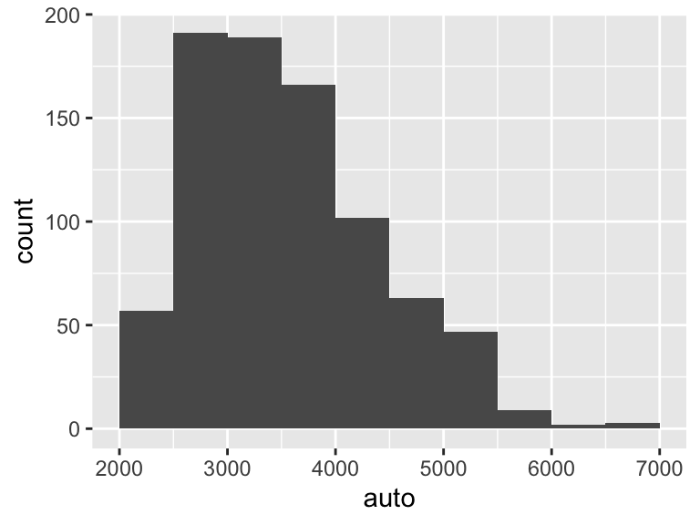

## creditcard

| Feature | Result |
| --- | --- |
| Variable type | numeric |
| Number of missing obs. | 3 (0.36 %) |
| Number of unique values | 232 |
| Median | 2970 |
| 1st and 3rd quartiles | 2610; 3360 |
| Min. and max. | 1040; 4850 |

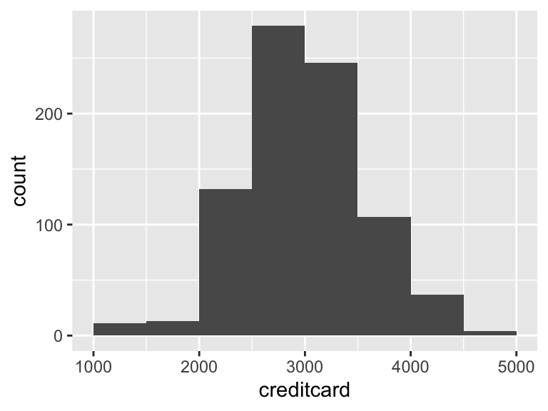

## mortgage

| Feature | Result |
| --- | --- |
| Variable type | numeric |
| Number of missing obs. | 3 (0.36 %) |
| Number of unique values | 731 |
| Median | 28030 |
| 1st and 3rd quartiles | 22880; 38240 |
| Min. and max. | 9600; 70100 |

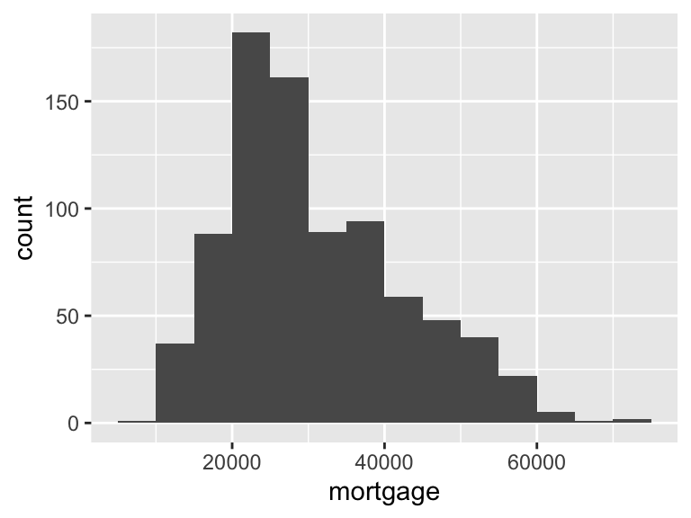

## studentloan

| Feature | Result |
| --- | --- |
| Variable type | numeric |
| Number of missing obs. | 3 (0.36 %) |
| Number of unique values | 432 |
| Median | 3690 |
| 1st and 3rd quartiles | 2360; 4750 |
| Min. and max. | 650; 13420 |

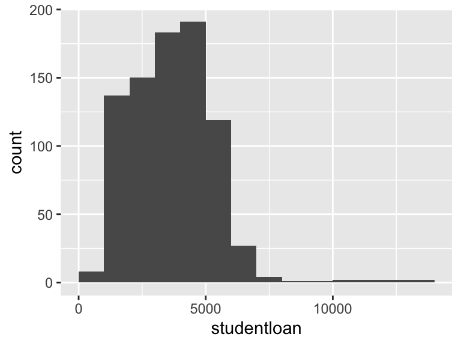

## auto_delinq

| Feature | Result |
| --- | --- |
| Variable type | numeric |
| Number of missing obs. | 3 (0.36 %) |
| Number of unique values | 510 |
| Median | 3.05 |
| 1st and 3rd quartiles | 2.26; 4.3 |
| Min. and max. | 0.91; 9.79 |

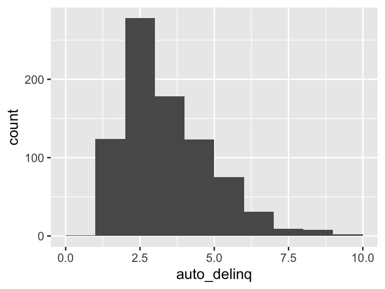

## creditcard_delinq

| Feature | Result |
| --- | --- |
| Variable type | numeric |
| Number of missing obs. | 3 (0.36 %) |
| Number of unique values | 598 |
| Median | 8.19 |
| 1st and 3rd quartiles | 6.83; 9.82 |
| Min. and max. | 3.61; 22.35 |

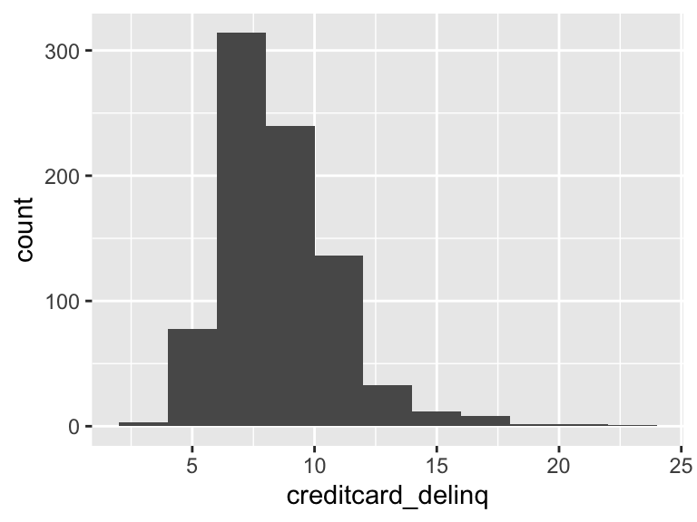

## mortgage_delinq

| Feature | Result |
| --- | --- |
| Variable type | numeric |
| Number of missing obs. | 3 (0.36 %) |
| Number of unique values | 567 |
| Median | 1.87 |
| 1st and 3rd quartiles | 1.12; 3.53 |
| Min. and max. | 0.3; 20.74 |

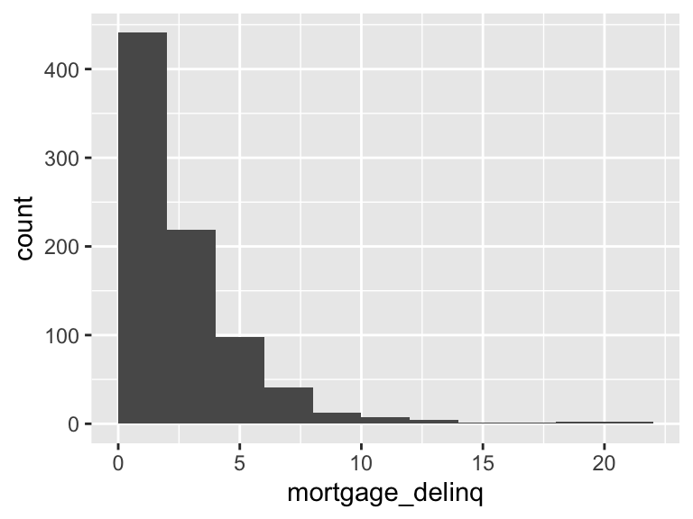

## studentloan_delinq

| Feature | Result |
| --- | --- |
| Variable type | numeric |
| Number of missing obs. | 3 (0.36 %) |
| Number of unique values | 659 |
| Median | 9.29 |
| 1st and 3rd quartiles | 7.34; 11.45 |
| Min. and max. | 3.16; 18.36 |

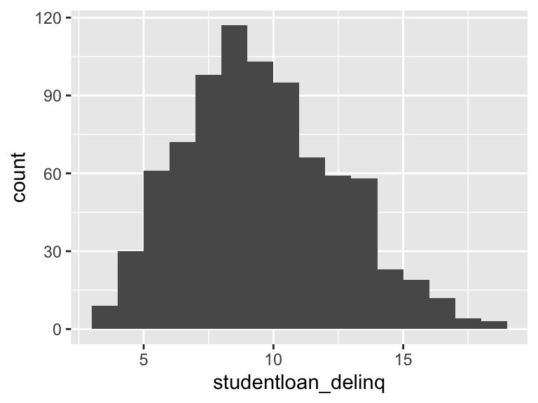

Report generation information:

- Created by: Natalie Meltzer (username: `nataliemeltzer`).
- Report creation time: Mon Feb 28 2022 20:30:22
- Report was run from directory: `/Users/nataliemeltzer/Library/CloudStorage/Box-Box/glhlth562/glhlth562final/proposal`
- dataReporter v1.0.2 [Pkg: 2021-11-11 from CRAN (R 4.1.0)]
- R version 4.1.2 (2021-11-01).
- Platform: x86_64-apple-darwin17.0 (64-bit)(macOS Big Sur 10.16).
- Function call: `dataReporter::makeDataReport(data = debtlevels, mode = c("summarize", "visualize", "check"), smartNum = FALSE, file = "codebook_debtlevels.Rmd", vol = "", checks = list(character = "showAllFactorLevels", factor = "showAllFactorLevels", labelled = "showAllFactorLevels", haven_labelled = "showAllFactorLevels", numeric = NULL, integer = NULL, logical = NULL, Date = NULL), listChecks = FALSE, maxProbVals = Inf, codebook = TRUE, reportTitle = "Codebook for debtlevels")`